# Lab Report #2 Solutions

DATA101: Introduction to Data Science

**In this lab report, you are to again analyse the “Bike Share” dataset that you analysed in the previous lab report. The dataset is available under the “Datasets” section of the DATA101 Blackboard page. The aim of the report is to understand trends in the data using summary statistics and graphical displays.**

1. **Provide an appropriate graphical display to visualise bike shares (`Count`) over time. Use an appropriate aggregation of hourly bike shares data to visualise the time trend, and comment on why the trend may be as shown in your graphical display.**

   **Solution:**

   It would make most sense to aggregate into monthly totals, as shown below. A line plot of these totals is presented below and shows a cyclical pattern which is strongly related to seasons. In particular, the months of December to February correspond to low numbers of bike shares, and these are winter months for London. At the same time, June to August correspond to high numbers of bike shares, and these are summer months for London. We would naturally expect more people to want to use bicycles when the weather is a bit warmer, so that could explain higher numbers of bike shares in summer months. Additionally, we would expect tourist numbers to be higher in summer months, potentially leading to higher usage of public-use bikes.

   | Month-Year | Total Bike Shares |
   | --- | --- |
   | Jan.-2015 | 546,639 |
   | Feb.-2015 | 543,594 |
   | Mar.-2015 | 695,934 |
   | Apr.-2015 | 831,582 |
   | May-2015 | 895,413 |
   | Jun.-2015 | 1,033,252 |
   | Jul.-2015 | 1,120,687 |
   | Aug.-2015 | 1,033,951 |
   | Sep.-2015 | 892,478 |
   | Oct.-2015 | 865,046 |
   | Nov.-2015 | 677,332 |
   | Dec.-2015 | 602,838 |
   | Jan.-2016 | 582,518 |
   | Feb.-2016 | 592,910 |
   | Mar.-2016 | 656,527 |
   | Apr.-2016 | 768,845 |
   | May-2016 | 1,001,935 |
   | Jun.-2016 | 933,878 |
   | Jul.-2016 | 1,165,527 |
   | Aug.-2016 | 1,137,314 |
   | Sep.-2016 | 998,619 |
   | Oct.-2016 | 935,706 |
   | Nov.-2016 | 703,859 |
   | Dec.-2016 | 651,908 |

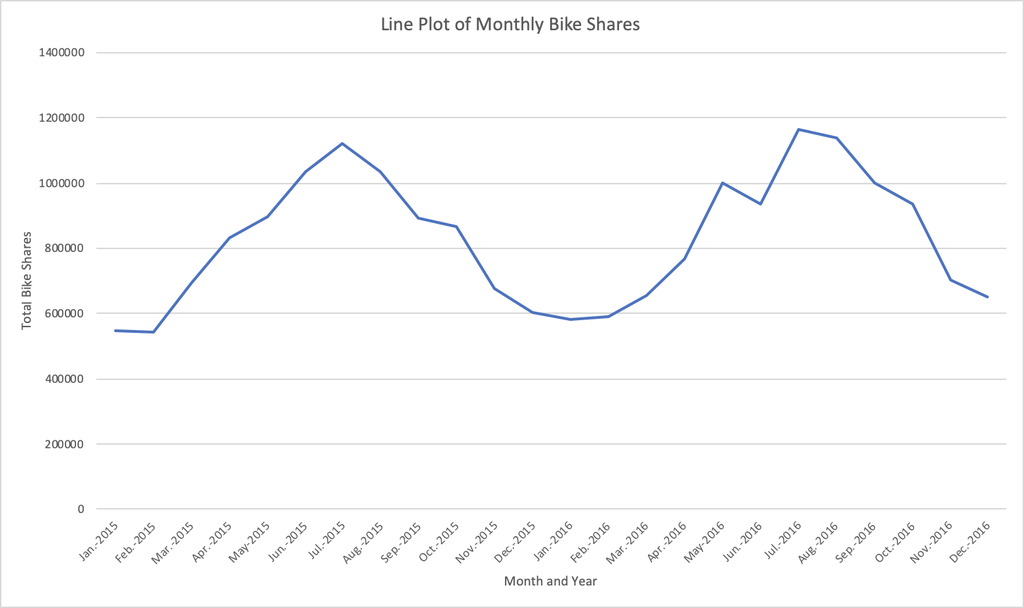

2. **Now provide a graphical display that additionally shows average “feels like” temperatures over time, again for the same aggregation of time points considered in Question 1. What appears to be the relationship between bike shares and average “feels like” temperature? Also provide an appropriate statistical measure of the association between bike shares and average “feels like” temperature (for the aggregation of time points used to produce your graphical display), and comment on what this suggests about the relationship between bike shares and average “feels like” temperature.**

   **Solution:**

   Again using monthly totals, we get the total bike shares and average temperatures shown below.

   | Month-Year | Total Bike Shares | Average Temperature |
   | --- | --- | --- |
   | Jan.-2015 | 546639 | 3.361400894 |
   | Feb.-2015 | 543594 | 2.78390462 |
   | Mar.-2015 | 695934 | 6.168470907 |
   | Apr.-2015 | 831582 | 9.892211405 |
   | May-2015 | 895413 | 13.17674731 |
   | Jun.-2015 | 1033252 | 16.83821478 |
   | Jul.-2015 | 1120687 | 19 |
   | Aug.-2015 | 1033951 | 18.57056452 |
   | Sep.-2015 | 892478 | 14.56751055 |
   | Oct.-2015 | 865046 | 12.66508152 |
   | Nov.-2015 | 677332 | 10.69620253 |
   | Dec.-2015 | 602838 | 11.7027027 |
   | Jan.-2016 | 582518 | 5.204301075 |
   | Feb.-2016 | 592910 | 4.408430233 |
   | Mar.-2016 | 656527 | 5.054183813 |
   | Apr.-2016 | 768845 | 7.939499305 |
   | May-2016 | 1001935 | 14.16330645 |
   | Jun.-2016 | 933878 | 16.42340426 |
   | Jul.-2016 | 1165527 | 19.50539811 |
   | Aug.-2016 | 1137314 | 19.84662162 |
   | Sep.-2016 | 998619 | 18.74084919 |
   | Oct.-2016 | 935706 | 12.43584567 |
   | Nov.-2016 | 703859 | 6.257997218 |
   | Dec.-2016 | 651908 | 6.619623656 |

   Producing a line plot of average temperature over time, we get the plot shown below. The plot seems to show a cyclical trend in average temperatures reflecting the seasons in London and closely matching the trend in bike shares, suggesting that the two are related and positively so (*i.e.*, as the one increases, so does the other).

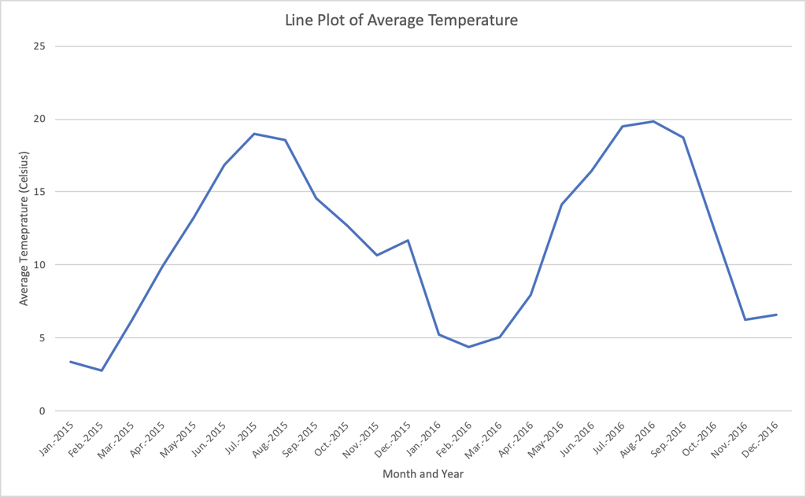

   Alternatively, we could plot both bike shares and average temperatures over time using line plots but with multiple *y*-axes, producing the plot shown below. This plot also seems to show the trend in average temperatures closely matching the trend in bike shares, suggesting that the two are related and positively so (*i.e.*, as the one increases, so does the other).

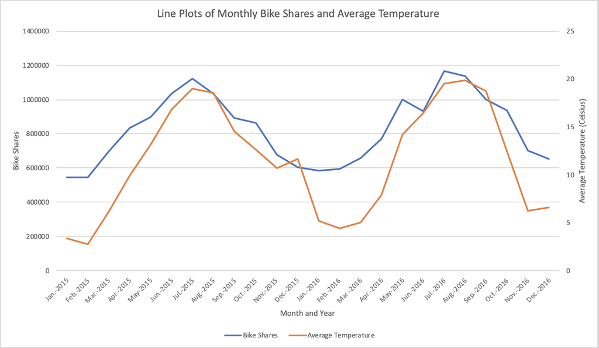

   To measure the association between monthly bike shares and monthly average temperature, we can use the correlation coefficient. The correlation coefficient is $r = 0.9344$, which is positive and very close to 1. This suggests a strong, positive relationship between monthly average temperature and monthly bike shares.

   | Correlation | Bike Shares | Average Temperature |
   | --- | --- | --- |
   | Bike Shares | 1 | 0.934407619 |
   | Average Temperature | 0.934407619 | 1 |

3. **Perform an appropriate analysis to compare the weather (`Weather_Code`) for the various seasons, being sure to provide a graphical display that can be used to effectively visualise this. Describe some of the key changes in weather that can be observed from season to season.**

   **Solution:**

   The following table shows the proportion of hourly weather measurements that are classified according to the various weather categories for each season:

   | Weather | Spring | Summer | Autumn | Winter |
   | --- | --- | --- | --- | --- |
   | Clear; mostly clear with some haze/fog/patches of fog in the vicinity | 0.398725535 | 0.415317985 | 0.31512898 | 0.279473931 |
   | Scattered clouds/few clouds | 0.21734183 | 0.255071803 | 0.24029746 | 0.215829028 |
   | Broken clouds | 0.182976787 | 0.176658309 | 0.234952359 | 0.222639737 |
   | Cloudy | 0.07419208 | 0.04923638 | 0.086451313 | 0.127524659 |
   | Rain/light rain shower | 0.123805189 | 0.102575792 | 0.120613525 | 0.144199155 |
   | Rain with thunderstorm | 0.001593081 | 0.001139731 | 0.000232396 | 0.000234852 |
   | Snowfall | 0.001365498 | 0 | 0.00232396 | 0.010098638 |

   The weather categories seem to fall along a scale related to level of cloud cover and associated condensation in clouds, and it would seem reasonable to treat these as ordinal. Consequently, I have chosen to represent the comparison of weather (variable of interest) for various seasons (grouping variable) using a stacked barplot. This shows that clear weather is highest for summer and spring, followed by autumn and then winter. Summer has the least cloudy, rainy, and snowy days, whereas spring and autumn are quite similar. Winter has far more cloudy, rainy, and snowy days than other seasons.

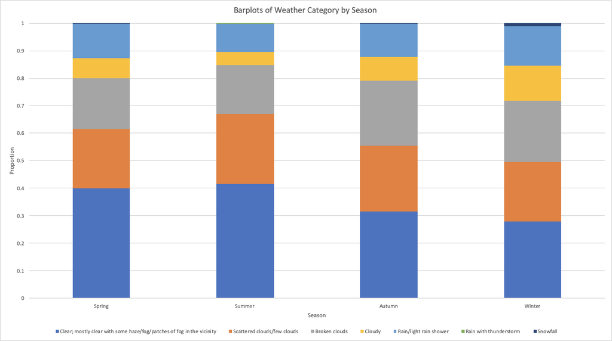

4. **Finally, use a single visual display to represent the relationship among monthly average temperature, average humidity, and average wind speed. Comment on any noticeable trend(s).**

   **Solution:**

   Using monthly totals, we get the average “feels like” temperatures, humidity, and wind speeds shown below.

   | Average Temperature | Average Humidity | Average Wind Speed |
   | --- | --- | --- |
   | 3.361400894 | 76.01341282 | 18.6318927 |
   | 2.78390462 | 77.42175857 | 14.71460507 |
   | 6.168470907 | 70.13836265 | 17.50778078 |
   | 9.892211405 | 67.41029207 | 15.28303199 |
   | 13.17674731 | 64.43413978 | 19.1780914 |
   | 16.83821478 | 61.88493724 | 17.29149233 |
   | 19 | 63.01689189 | 17.65810811 |
   | 18.57056452 | 69.77620968 | 13.87903226 |
   | 14.56751055 | 73.13924051 | 13.21237693 |
   | 12.66508152 | 78.65081522 | 11.78147645 |
   | 10.69620253 | 79.24683544 | 19.95921238 |
   | 11.7027027 | 76.28175676 | 20.88175676 |
   | 5.204301075 | 78.26680108 | 17.46841398 |
   | 4.408430233 | 72.45203488 | 18.98037791 |
   | 5.054183813 | 73.69341564 | 16.1563786 |
   | 7.939499305 | 67.65438108 | 15.3922114 |
   | 14.16330645 | 68.30040323 | 14.78696237 |
   | 16.42340426 | 76.12553191 | 13.82269504 |
   | 19.50539811 | 65.74831309 | 15.98785425 |
   | 19.84662162 | 64.78918919 | 16.0277027 |
   | 18.74084919 | 70.31039531 | 14.02635432 |
   | 12.43584567 | 76.63795424 | 12.55540601 |
   | 6.257997218 | 78.22392211 | 14.60222531 |
   | 6.619623656 | 85.75739247 | 12.38776882 |

   We can represent the relationshipi among all three of these numeric variables using a bubble plot. There are a number of ways that this could be expressed in terms of the variable corresponding to the horizontal axis, the variable corresponding to the vertical axis, and the the variable corresponding to the bubble size. I have chosen to place the average “feels like” temperature on the horizontal axis and average humidity on the vertical axis, and the average wind speed is used to represent bubble size, which I have scaled down in size from Excel’s defaults. It is not clear how wind speed relates to temperature and/or humdity, as bubble sizes do not fluctuate much (because average wind speeds do not fluctuate much) and do not show a clear trend when looking from left to right or from bottom to top in the bubble plot. There appears to be a decreasing trend in humidity as “feels like” temperature increases (*i.e.*, there is a negative relationship between humidity and “feels like” temperature). This is likely a moderate association/correlation, as, although the decreasing trend is apparent, there is still a fair bit of scatter in the points on the bubble plot.

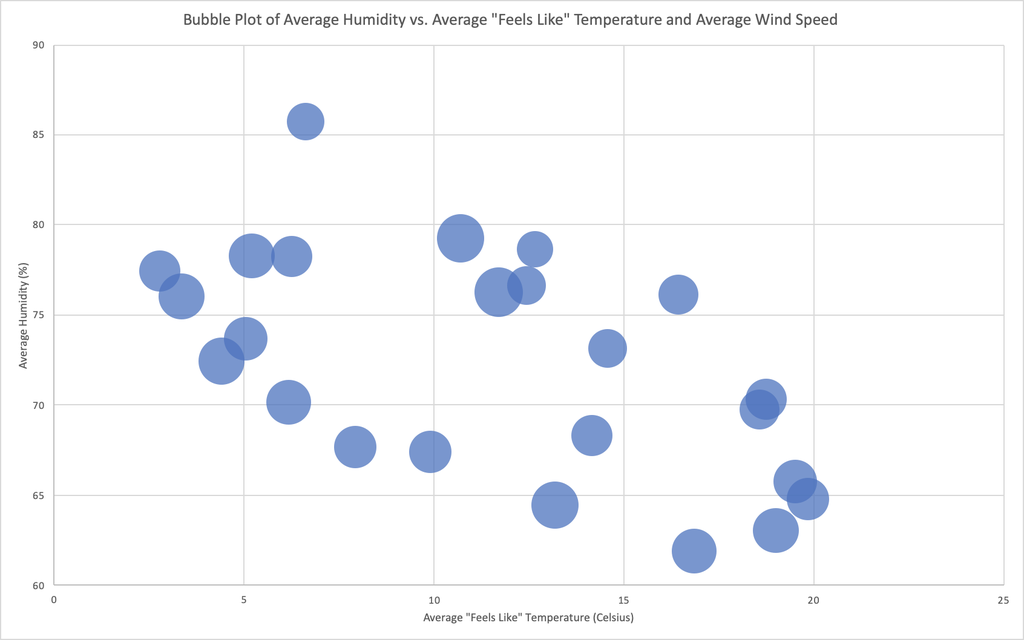